# figure2

Below is a plot of the differences between regulated and unregulated category gene biotypes...... some of these categories are massively insignifigant 0.03%> and will not be included in the following figures in this notebook

```
Reading file: /mnt/work_1/gsgeorge/mus_musculus/figure2/output/Spleen/Spleen_upregulated_annotated.csv
Columns in /mnt/work_1/gsgeorge/mus_musculus/figure2/output/Spleen/Spleen_upregulated_annotated.csv: ['ID', 'log2FoldChange', 'pvalue', 'padj', 'KO1.ZC158.M', 'KO2.ZC159.M', 'KO3.ZC151.F', 'KO4.ZC109.M', 'WT1.ZC128.F', 'WT2.ZC161.M', 'WT3.ZC143.F', 'WT3.ZC162.M', 'Gene.name', 'gene_biotype', 'Coding…
Reading file: /mnt/work_1/gsgeorge/mus_musculus/figure2/output/Spleen/Spleen_downregulated_annotated.csv
Columns in /mnt/work_1/gsgeorge/mus_musculus/figure2/output/Spleen/Spleen_downregulated_annotated.csv: ['ID', 'log2FoldChange', 'pvalue', 'padj', 'KO1.ZC158.M', 'KO2.ZC159.M', 'KO3.ZC151.F', 'KO4.ZC109.M', 'WT1.ZC128.F', 'WT2.ZC161.M', 'WT3.ZC143.F', 'WT3.ZC162.M', 'Gene.name', 'gene_biotype', 'Codi…
Reading file: /mnt/work_1/gsgeorge/mus_musculus/figure2/output/Spleen/Spleen_unregulated_annotated.csv
Columns in /mnt/work_1/gsgeorge/mus_musculus/figure2/output/Spleen/Spleen_unregulated_annotated.csv: ['ID', 'log2FoldChange', 'pvalue', 'padj', 'KO1.ZC158.M', 'KO2.ZC159.M', 'KO3.ZC151.F', 'KO4.ZC109.M', 'WT1.ZC128.F', 'WT2.ZC161.M', 'WT3.ZC143.F', 'WT3.ZC162.M', 'Gene.name', 'gene_biotype', 'Coding…
Reading file: /mnt/work_1/gsgeorge/mus_musculus/figure2/output/Liver/Liver_upregulated_annotated.csv
Columns in /mnt/work_1/gsgeorge/mus_musculus/figure2/output/Liver/Liver_upregulated_annotated.csv: ['ID', 'log2FoldChange', 'pvalue', 'padj', 'KO1.liver', 'KO2.liver', 'KO3.liver', 'KO4.liver', 'KO5.liver', 'WT1.liver', 'WT2.liver', 'WT3.liver', 'WT4.liver', 'WT5.liver', 'Gene.name', 'gene_biotype',…
Reading file: /mnt/work_1/gsgeorge/mus_musculus/figure2/output/Liver/Liver_downregulated_annotated.csv
Columns in /mnt/work_1/gsgeorge/mus_musculus/figure2/output/Liver/Liver_downregulated_annotated.csv: ['ID', 'log2FoldChange', 'pvalue', 'padj', 'KO1.liver', 'KO2.liver', 'KO3.liver', 'KO4.liver', 'KO5.liver', 'WT1.liver', 'WT2.liver', 'WT3.liver', 'WT4.liver', 'WT5.liver', 'Gene.name', 'gene_biotype…
Reading file: /mnt/work_1/gsgeorge/mus_musculus/figure2/output/Liver/Liver_unregulated_annotated.csv
Columns in /mnt/work_1/gsgeorge/mus_musculus/figure2/output/Liver/Liver_unregulated_annotated.csv: ['ID', 'log2FoldChange', 'pvalue', 'padj', 'KO1.liver', 'KO2.liver', 'KO3.liver', 'KO4.liver', 'KO5.liver', 'WT1.liver', 'WT2.liver', 'WT3.liver', 'WT4.liver', 'WT5.liver', 'Gene.name', 'gene_biotype',…
Reading file: /mnt/work_1/gsgeorge/mus_musculus/figure2/output/BM/BM_upregulated_annotated.csv
Columns in /mnt/work_1/gsgeorge/mus_musculus/figure2/output/BM/BM_upregulated_annotated.csv: ['ID', 'log2FoldChange', 'pvalue', 'padj', 'KO1.BMcells', 'KO2.BMcells', 'KO3.BMcells', 'KO4.BMcells', 'KO5.BMcells', 'WT1.BMcells', 'WT2.BMcells', 'WT3.BMcells', 'WT4.BMcells', 'WT5.BMcells', 'Gene.name', '…
Reading file: /mnt/work_1/gsgeorge/mus_musculus/figure2/output/BM/BM_downregulated_annotated.csv
Columns in /mnt/work_1/gsgeorge/mus_musculus/figure2/output/BM/BM_downregulated_annotated.csv: ['ID', 'log2FoldChange', 'pvalue', 'padj', 'KO1.BMcells', 'KO2.BMcells', 'KO3.BMcells', 'KO4.BMcells', 'KO5.BMcells', 'WT1.BMcells', 'WT2.BMcells', 'WT3.BMcells', 'WT4.BMcells', 'WT5.BMcells', 'Gene.name',…
Reading file: /mnt/work_1/gsgeorge/mus_musculus/figure2/output/BM/BM_unregulated_annotated.csv
Columns in /mnt/work_1/gsgeorge/mus_musculus/figure2/output/BM/BM_unregulated_annotated.csv: ['ID', 'log2FoldChange', 'pvalue', 'padj', 'KO1.BMcells', 'KO2.BMcells', 'KO3.BMcells', 'KO4.BMcells', 'KO5.BMcells', 'WT1.BMcells', 'WT2.BMcells', 'WT3.BMcells', 'WT4.BMcells', 'WT5.BMcells', 'Gene.name', '…
Reading file: /mnt/work_1/gsgeorge/mus_musculus/figure2/output/Ovary/Ovary_upregulated_annotated.csv
Columns in /mnt/work_1/gsgeorge/mus_musculus/figure2/output/Ovary/Ovary_upregulated_annotated.csv: ['ID', 'log2FoldChange', 'pvalue', 'padj', 'WT1.ZC150', 'KO1.ZC151', 'KO2.ZC205', 'WT3.ZC210', 'WT4.ZC256', 'KO4.ZC257', 'Gene.name', 'gene_biotype', 'Coding/Non-coding', 'Regulation']
Reading file: /mnt/work_1/gsgeorge/mus_musculus/figure2/output/Ovary/Ovary_downregulated_annotated.csv
Columns in /mnt/work_1/gsgeorge/mus_musculus/figure2/output/Ovary/Ovary_downregulated_annotated.csv: ['ID', 'log2FoldChange', 'pvalue', 'padj', 'WT1.ZC150', 'KO1.ZC151', 'KO2.ZC205', 'WT3.ZC210', 'WT4.ZC256', 'KO4.ZC257', 'Gene.name', 'gene_biotype', 'Coding/Non-coding', 'Regulation']
Reading file: /mnt/work_1/gsgeorge/mus_musculus/figure2/output/Ovary/Ovary_unregulated_annotated.csv
Columns in /mnt/work_1/gsgeorge/mus_musculus/figure2/output/Ovary/Ovary_unregulated_annotated.csv: ['ID', 'log2FoldChange', 'pvalue', 'padj', 'WT1.ZC150', 'KO1.ZC151', 'KO2.ZC205', 'WT3.ZC210', 'WT4.ZC256', 'KO4.ZC257', 'Gene.name', 'gene_biotype', 'Coding/Non-coding', 'Regulation']
```

[output cut: 12 more lines]

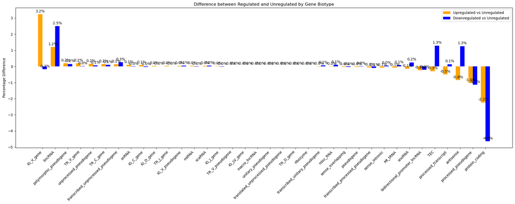

```python
import pandas as pd
import numpy as np
import matplotlib.pyplot as plt
import os
import glob

base_path = '/mnt/work_1/gsgeorge/mus_musculus/figure2/output'  # Adjusted base path
regulation_types = ['upregulated', 'downregulated', 'unregulated']
output_dir = '/mnt/work_1/gsgeorge/mus_musculus/figure2/output/all_output'
if not os.path.exists(output_dir):
    os.makedirs(output_dir)

# Dictionary to store data frames for each regulation type across all tissues
dfs = {reg_type: pd.DataFrame() for reg_type in regulation_types}

# Iterate through each tissue, then load and concatenate files per regulation type
for tissue in os.listdir(base_path):
    tissue_dir = os.path.join(base_path, tissue)
    if os.path.isdir(tissue_dir):
        for reg_type in regulation_types:
            pattern = f'{tissue_dir}/{tissue}_{reg_type}_annotated.csv'
            for file in glob.glob(pattern):
                print(f"Reading file: {file}")
                temp_df = pd.read_csv(file)
                print(f"Columns in {file}: {temp_df.columns.tolist()}")
                if 'gene_biotype' not in temp_df.columns:
                    print(f"Warning: 'gene_biotype' column not found in {file}. Skipping this file.")
                    continue
                dfs[reg_type] = pd.concat([dfs[reg_type], temp_df], ignore_index=True)

# Dictionary to store percentages for each gene biotype
gene_biotype_percentages = {reg_type: {} for reg_type in regulation_types}

for reg_type in regulation_types:
    data = dfs[reg_type]
    if 'gene_biotype' not in data.columns:
        print(f"Warning: 'gene_biotype' column not found in combined DataFrame for {reg_type}.")
        continue
    # Count occurrences and calculate percentage for each gene biotype
    total = len(data)
    counts = data['gene_biotype'].value_counts()
    percentages = (counts / total) * 100
    gene_biotype_percentages[reg_type] = percentages.to_dict()

# Identifying all gene biotypes
all_gene_types = set()
for reg_type in gene_biotype_percentages:
    all_gene_types.update(gene_biotype_percentages[reg_type].keys())

# Function to calculate difference in percentage
def calc_diff(up_or_down_type, g_type):
    unregulated = gene_biotype_percentages['unregulated'].get(g_type, 0)
    regulated = gene_biotype_percentages[up_or_down_type].get(g_type, 0)
    return regulated - unregulated

# Preparing difference calculations
gene_biotype_diffs = [
     (g_type, calc_diff('upregulated', g_type), calc_diff('downregulated', g_type))
    for g_type in all_gene_types
]

# Sorting based on the upregulated differences
gene_biotype_diffs.sort(key=lambda x: x[1], reverse=True)  # Sort by upregulated differences

# Unpacking the sorted data
gene_types_sorted, up_diffs, down_diffs = zip(*gene_biotype_diffs)

ind = np.arange(len(gene_types_sorted))
fig, ax = plt.subplots(figsize=(20, 8))
width = 0.35
ind = np.arange(len(gene_types_sorted))
rects1 = ax.bar(ind - width / 2, up_diffs, width, label='Upregulated vs Unregulated', color="orange")
rects2 = ax.bar(ind + width / 2, down_diffs, width, label='Downregulated vs Unregulated', color="blue")

ax.set_ylabel('Percentage Difference')
ax.set_title('Difference between Regulated and Unregulated by Gene Biotype')
ax.set_xticks(ind)
ax.set_xticklabels(gene_types_sorted, rotation=45, ha="right")
ax.legend()

def attach_annotations(rects):
    for rect in rects:
        height = rect.get_height()
        ax.annotate(f'{height:.1f}%', xy=(rect.get_x() + rect.get_width() / 2, height),
                    xytext=(0, 3), textcoords="offset points",
                    ha='center', va='bottom')

attach_annotations(rects1)
attach_annotations(rects2)

plt.tight_layout()
biotype_plot_path = os.path.join(output_dir, "Biotype_differences_plot_all_tissues.svg")
plt.savefig(biotype_plot_path, format="svg", bbox_inches='tight')
plt.show()
```

```
Reading file: /mnt/work_1/gsgeorge/mus_musculus/figure2/output/Spleen/Spleen_upregulated_annotated.csv
Columns in /mnt/work_1/gsgeorge/mus_musculus/figure2/output/Spleen/Spleen_upregulated_annotated.csv: ['ID', 'log2FoldChange', 'pvalue', 'padj', 'KO1.ZC158.M', 'KO2.ZC159.M', 'KO3.ZC151.F', 'KO4.ZC109.M', 'WT1.ZC128.F', 'WT2.ZC161.M', 'WT3.ZC143.F', 'WT3.ZC162.M', 'Gene.name', 'gene_biotype', 'Coding…
Reading file: /mnt/work_1/gsgeorge/mus_musculus/figure2/output/Spleen/Spleen_downregulated_annotated.csv
Columns in /mnt/work_1/gsgeorge/mus_musculus/figure2/output/Spleen/Spleen_downregulated_annotated.csv: ['ID', 'log2FoldChange', 'pvalue', 'padj', 'KO1.ZC158.M', 'KO2.ZC159.M', 'KO3.ZC151.F', 'KO4.ZC109.M', 'WT1.ZC128.F', 'WT2.ZC161.M', 'WT3.ZC143.F', 'WT3.ZC162.M', 'Gene.name', 'gene_biotype', 'Codi…
Reading file: /mnt/work_1/gsgeorge/mus_musculus/figure2/output/Spleen/Spleen_unregulated_annotated.csv
Columns in /mnt/work_1/gsgeorge/mus_musculus/figure2/output/Spleen/Spleen_unregulated_annotated.csv: ['ID', 'log2FoldChange', 'pvalue', 'padj', 'KO1.ZC158.M', 'KO2.ZC159.M', 'KO3.ZC151.F', 'KO4.ZC109.M', 'WT1.ZC128.F', 'WT2.ZC161.M', 'WT3.ZC143.F', 'WT3.ZC162.M', 'Gene.name', 'gene_biotype', 'Coding…
Reading file: /mnt/work_1/gsgeorge/mus_musculus/figure2/output/Liver/Liver_upregulated_annotated.csv
Columns in /mnt/work_1/gsgeorge/mus_musculus/figure2/output/Liver/Liver_upregulated_annotated.csv: ['ID', 'log2FoldChange', 'pvalue', 'padj', 'KO1.liver', 'KO2.liver', 'KO3.liver', 'KO4.liver', 'KO5.liver', 'WT1.liver', 'WT2.liver', 'WT3.liver', 'WT4.liver', 'WT5.liver', 'Gene.name', 'gene_biotype',…
Reading file: /mnt/work_1/gsgeorge/mus_musculus/figure2/output/Liver/Liver_downregulated_annotated.csv
Columns in /mnt/work_1/gsgeorge/mus_musculus/figure2/output/Liver/Liver_downregulated_annotated.csv: ['ID', 'log2FoldChange', 'pvalue', 'padj', 'KO1.liver', 'KO2.liver', 'KO3.liver', 'KO4.liver', 'KO5.liver', 'WT1.liver', 'WT2.liver', 'WT3.liver', 'WT4.liver', 'WT5.liver', 'Gene.name', 'gene_biotype…
Reading file: /mnt/work_1/gsgeorge/mus_musculus/figure2/output/Liver/Liver_unregulated_annotated.csv
Columns in /mnt/work_1/gsgeorge/mus_musculus/figure2/output/Liver/Liver_unregulated_annotated.csv: ['ID', 'log2FoldChange', 'pvalue', 'padj', 'KO1.liver', 'KO2.liver', 'KO3.liver', 'KO4.liver', 'KO5.liver', 'WT1.liver', 'WT2.liver', 'WT3.liver', 'WT4.liver', 'WT5.liver', 'Gene.name', 'gene_biotype',…
Reading file: /mnt/work_1/gsgeorge/mus_musculus/figure2/output/BM/BM_upregulated_annotated.csv
Columns in /mnt/work_1/gsgeorge/mus_musculus/figure2/output/BM/BM_upregulated_annotated.csv: ['ID', 'log2FoldChange', 'pvalue', 'padj', 'KO1.BMcells', 'KO2.BMcells', 'KO3.BMcells', 'KO4.BMcells', 'KO5.BMcells', 'WT1.BMcells', 'WT2.BMcells', 'WT3.BMcells', 'WT4.BMcells', 'WT5.BMcells', 'Gene.name', '…
Reading file: /mnt/work_1/gsgeorge/mus_musculus/figure2/output/BM/BM_downregulated_annotated.csv
Columns in /mnt/work_1/gsgeorge/mus_musculus/figure2/output/BM/BM_downregulated_annotated.csv: ['ID', 'log2FoldChange', 'pvalue', 'padj', 'KO1.BMcells', 'KO2.BMcells', 'KO3.BMcells', 'KO4.BMcells', 'KO5.BMcells', 'WT1.BMcells', 'WT2.BMcells', 'WT3.BMcells', 'WT4.BMcells', 'WT5.BMcells', 'Gene.name',…
Reading file: /mnt/work_1/gsgeorge/mus_musculus/figure2/output/BM/BM_unregulated_annotated.csv
Columns in /mnt/work_1/gsgeorge/mus_musculus/figure2/output/BM/BM_unregulated_annotated.csv: ['ID', 'log2FoldChange', 'pvalue', 'padj', 'KO1.BMcells', 'KO2.BMcells', 'KO3.BMcells', 'KO4.BMcells', 'KO5.BMcells', 'WT1.BMcells', 'WT2.BMcells', 'WT3.BMcells', 'WT4.BMcells', 'WT5.BMcells', 'Gene.name', '…
Reading file: /mnt/work_1/gsgeorge/mus_musculus/figure2/output/Ovary/Ovary_upregulated_annotated.csv
Columns in /mnt/work_1/gsgeorge/mus_musculus/figure2/output/Ovary/Ovary_upregulated_annotated.csv: ['ID', 'log2FoldChange', 'pvalue', 'padj', 'WT1.ZC150', 'KO1.ZC151', 'KO2.ZC205', 'WT3.ZC210', 'WT4.ZC256', 'KO4.ZC257', 'Gene.name', 'gene_biotype', 'Coding/Non-coding', 'Regulation']
Reading file: /mnt/work_1/gsgeorge/mus_musculus/figure2/output/Ovary/Ovary_downregulated_annotated.csv
Columns in /mnt/work_1/gsgeorge/mus_musculus/figure2/output/Ovary/Ovary_downregulated_annotated.csv: ['ID', 'log2FoldChange', 'pvalue', 'padj', 'WT1.ZC150', 'KO1.ZC151', 'KO2.ZC205', 'WT3.ZC210', 'WT4.ZC256', 'KO4.ZC257', 'Gene.name', 'gene_biotype', 'Coding/Non-coding', 'Regulation']
Reading file: /mnt/work_1/gsgeorge/mus_musculus/figure2/output/Ovary/Ovary_unregulated_annotated.csv
Columns in /mnt/work_1/gsgeorge/mus_musculus/figure2/output/Ovary/Ovary_unregulated_annotated.csv: ['ID', 'log2FoldChange', 'pvalue', 'padj', 'WT1.ZC150', 'KO1.ZC151', 'KO2.ZC205', 'WT3.ZC210', 'WT4.ZC256', 'KO4.ZC257', 'Gene.name', 'gene_biotype', 'Coding/Non-coding', 'Regulation']
```

[output cut: 12 more lines]

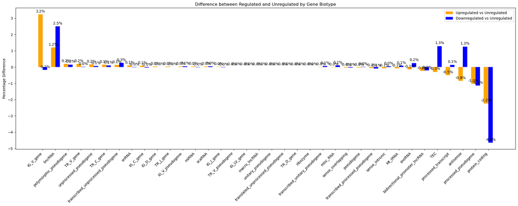

```python
import pandas as pd
import numpy as np
import matplotlib.pyplot as plt
import os
import glob

base_path = '/mnt/work_1/gsgeorge/mus_musculus/figure2/output'  # Adjusted base path
regulation_types = ['upregulated', 'downregulated', 'unregulated']
output_dir = '/mnt/work_1/gsgeorge/mus_musculus/figure2/output/all_output'
if not os.path.exists(output_dir):
    os.makedirs(output_dir)

# Dictionary to store data frames for each regulation type across all tissues
dfs = {reg_type: pd.DataFrame() for reg_type in regulation_types}

# Iterate through each tissue, then load and concatenate files per regulation type
for tissue in os.listdir(base_path):
    tissue_dir = os.path.join(base_path, tissue)
    if os.path.isdir(tissue_dir):
        for reg_type in regulation_types:
            pattern = f'{tissue_dir}/{tissue}_{reg_type}_annotated.csv'
            for file in glob.glob(pattern):
                print(f"Reading file: {file}")
                temp_df = pd.read_csv(file)
                print(f"Columns in {file}: {temp_df.columns.tolist()}")
                if 'gene_biotype' not in temp_df.columns:
                    print(f"Warning: 'gene_biotype' column not found in {file}. Skipping this file.")
                    continue
                dfs[reg_type] = pd.concat([dfs[reg_type], temp_df], ignore_index=True)

# Dictionary to store percentages for each gene biotype
gene_biotype_percentages = {reg_type: {} for reg_type in regulation_types}

for reg_type in regulation_types:
    data = dfs[reg_type]
    if 'gene_biotype' not in data.columns:
        print(f"Warning: 'gene_biotype' column not found in combined DataFrame for {reg_type}.")
        continue
    # Count occurrences and calculate percentage for each gene biotype
    total = len(data)
    counts = data['gene_biotype'].value_counts()
    percentages = (counts / total) * 100
    gene_biotype_percentages[reg_type] = percentages.to_dict()

# Identifying all gene biotypes
all_gene_types = set()
for reg_type in gene_biotype_percentages:
    all_gene_types.update(gene_biotype_percentages[reg_type].keys())

# Function to calculate difference in percentage
def calc_diff(up_or_down_type, g_type):
    unregulated = gene_biotype_percentages['unregulated'].get(g_type, 0)
    regulated = gene_biotype_percentages[up_or_down_type].get(g_type, 0)
    return regulated - unregulated

# Preparing difference calculations
gene_biotype_diffs = [
     (g_type, calc_diff('upregulated', g_type), calc_diff('downregulated', g_type))
    for g_type in all_gene_types
]

# Sorting based on the upregulated differences
gene_biotype_diffs.sort(key=lambda x: x[1], reverse=True)  # Sort by upregulated differences

# Unpacking the sorted data
gene_types_sorted, up_diffs, down_diffs = zip(*gene_biotype_diffs)

ind = np.arange(len(gene_types_sorted))
fig, ax = plt.subplots(figsize=(20, 8))
width = 0.35
ind = np.arange(len(gene_types_sorted))
rects1 = ax.bar(ind - width / 2, up_diffs, width, label='Upregulated vs Unregulated', color="orange")
rects2 = ax.bar(ind + width / 2, down_diffs, width, label='Downregulated vs Unregulated', color="blue")

ax.set_ylabel('Percentage Difference')
ax.set_title('Difference between Regulated and Unregulated by Gene Biotype')
ax.set_xticks(ind)
ax.set_xticklabels(gene_types_sorted, rotation=45, ha="right")
ax.legend()

def attach_annotations(rects):
    for rect in rects:
        height = rect.get_height()
        ax.annotate(f'{height:.1f}%', xy=(rect.get_x() + rect.get_width() / 2, height),
                    xytext=(0, 3), textcoords="offset points",
                    ha='center', va='bottom')

attach_annotations(rects1)
attach_annotations(rects2)

plt.tight_layout()
biotype_plot_path = os.path.join(output_dir, "Biotype_differences_plot_all_tissues.svg")
plt.savefig(biotype_plot_path, format="svg", bbox_inches='tight')
plt.show()
```

Now I am going to regenerate the same plot with the same color coordination, but this time, I am implementing a cutoff=0.5% with any biotype contributing less than that in both up and downregulated categories is included in the 'Other' category bar which I will further break down in subsequent code blocks

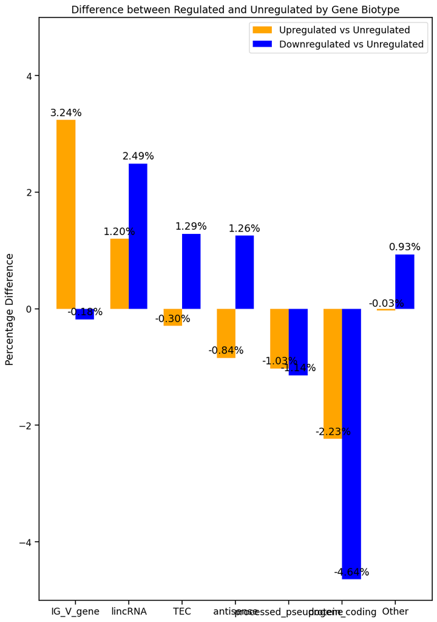

```python
import pandas as pd
import numpy as np
import matplotlib.pyplot as plt
import seaborn as sns
import os
import glob

# Set context for seaborn styling
sns.set_context("notebook", font_scale=1.15)

# Defined cutoff for differences
DIFFERENCE_CUTOFF = 0.5

base_path = '/mnt/work_1/gsgeorge/mus_musculus/figure2/output'
regulation_types = ['upregulated', 'downregulated', 'unregulated']
output_dir = '/mnt/work_1/gsgeorge/mus_musculus/figure2/output/all_output'

if not os.path.exists(output_dir):
    os.makedirs(output_dir)

dfs = {reg_type: pd.DataFrame() for reg_type in regulation_types}

for tissue in os.listdir(base_path):
    tissue_dir = os.path.join(base_path, tissue)
    if os.path.isdir(tissue_dir):
        for reg_type in regulation_types:
            for file in glob.glob(f'{tissue_dir}/{tissue}_{reg_type}_annotated.csv'):
                temp_df = pd.read_csv(file)
                dfs[reg_type] = pd.concat([dfs[reg_type], temp_df])

gene_biotype_percentages = {reg_type: {} for reg_type in regulation_types}

for reg_type in regulation_types:
    data = dfs[reg_type]
    total = len(data)
    counts = data['gene_biotype'].value_counts()
    percentages = (counts / total) * 100
    gene_biotype_percentages[reg_type] = percentages.to_dict()

all_gene_types = set()
for reg_type in gene_biotype_percentages.keys():
    all_gene_types.update(gene_biotype_percentages[reg_type].keys())

def calc_diff(up_or_down_type, g_type):
    unregulated = gene_biotype_percentages['unregulated'].get(g_type, 0)
    regulated = gene_biotype_percentages[up_or_down_type].get(g_type, 0)
    return regulated - unregulated

gene_biotype_diffs = []
other_category = ['Other', 0, 0]

for g_type in all_gene_types:
    up_diff = calc_diff('upregulated', g_type)
    down_diff = calc_diff('downregulated', g_type)
    if abs(up_diff) <= DIFFERENCE_CUTOFF and abs(down_diff) <= DIFFERENCE_CUTOFF:
        other_category[1] += up_diff  # Adding to 'Other' category for upregulated
        other_category[2] += down_diff  # Adding to 'Other' category for downregulated
    else:
        gene_biotype_diffs.append((g_type, up_diff, down_diff))

# Sort by upregulated differences first
gene_biotype_diffs.sort(key=lambda x: x[1], reverse=True)

# Append the 'Other' category last
gene_biotype_diffs.append(tuple(other_category))

gene_types_sorted, up_diffs, down_diffs = zip(*gene_biotype_diffs)
ind = np.arange(len(gene_types_sorted))

fig, ax = plt.subplots(figsize=(8.5, 12))

width = 0.35

rects1 = ax.bar(ind - width/2, up_diffs, width, label='Upregulated vs Unregulated', color="orange")
rects2 = ax.bar(ind + width/2, down_diffs, width, label='Downregulated vs Unregulated', color="blue")

ax.set_ylabel('Percentage Difference')
ax.set_title('Difference between Regulated and Unregulated by Gene Biotype')
ax.set_xticks(ind)
ax.set_xticklabels(gene_types_sorted)
ax.legend()

def attach_annotations(rects):
    for rect in rects:
        height = rect.get_height()
        ax.annotate(f'{height:.2f}%', xy=(rect.get_x() + rect.get_width() / 2, height),
                    xytext=(0, 3), textcoords="offset points",
                    ha='center', va='bottom')

attach_annotations(rects1)
attach_annotations(rects2)

plt.tight_layout()
plt.ylim(-5, 5)
biotype_plot_path = os.path.join(output_dir, "Biotype_differences_plot_with_cutoff_all_tissues.svg")
plt.savefig(biotype_plot_path, format="svg", bbox_inches='tight')
plt.show()
```

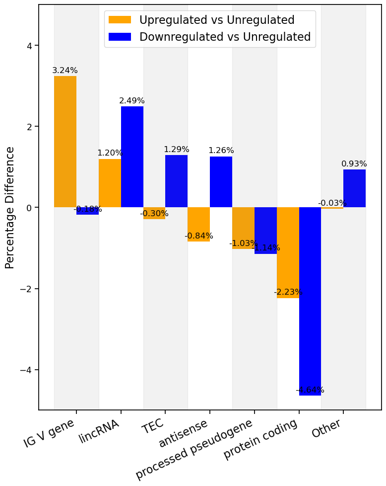

```python
import pandas as pd
import numpy as np
import matplotlib.pyplot as plt
import seaborn as sns
import os
import glob

# Set context for seaborn styling
sns.set_context("notebook", font_scale=1.15)

# Defined cutoff for differences
DIFFERENCE_CUTOFF = 0.5
base_path = '/mnt/work_1/gsgeorge/mus_musculus/figure2/output'
regulation_types = ['upregulated', 'downregulated', 'unregulated']
output_dir = '/mnt/work_1/gsgeorge/mus_musculus/figure2/output/all_output'
if not os.path.exists(output_dir):
    os.makedirs(output_dir)

dfs = {reg_type: pd.DataFrame() for reg_type in regulation_types}
for tissue in os.listdir(base_path):
    tissue_dir = os.path.join(base_path, tissue)
    if os.path.isdir(tissue_dir):
        for reg_type in regulation_types:
            for file in glob.glob(f'{tissue_dir}/{tissue}_{reg_type}_annotated.csv'):
                temp_df = pd.read_csv(file)
                dfs[reg_type] = pd.concat([dfs[reg_type], temp_df])

gene_biotype_percentages = {reg_type: {} for reg_type in regulation_types}
for reg_type in regulation_types:
    data = dfs[reg_type]
    total = len(data)
    counts = data['gene_biotype'].value_counts()
    percentages = (counts / total) * 100
    gene_biotype_percentages[reg_type] = percentages.to_dict()

all_gene_types = set()
for reg_type in gene_biotype_percentages.keys():
    all_gene_types.update(gene_biotype_percentages[reg_type].keys())

def calc_diff(up_or_down_type, g_type):
    unregulated = gene_biotype_percentages['unregulated'].get(g_type, 0)
    regulated = gene_biotype_percentages[up_or_down_type].get(g_type, 0)
    return regulated - unregulated

gene_biotype_diffs = []
other_category = ['Other', 0, 0]
for g_type in all_gene_types:
    up_diff = calc_diff('upregulated', g_type)
    down_diff = calc_diff('downregulated', g_type)
    if abs(up_diff) <= DIFFERENCE_CUTOFF and abs(down_diff) <= DIFFERENCE_CUTOFF:
        other_category[1] += up_diff  # Adding to 'Other' category for upregulated
        other_category[2] += down_diff  # Adding to 'Other' category for downregulated
    else:
        gene_biotype_diffs.append((g_type, up_diff, down_diff))

gene_biotype_diffs.sort(key=lambda x: x[1], reverse=True)
gene_biotype_diffs.append(tuple(other_category))

gene_types_sorted, up_diffs, down_diffs = zip(*gene_biotype_diffs)
ind = np.arange(len(gene_types_sorted))

# Replace underscores with spaces in gene_types_sorted
gene_types_sorted = [gt.replace("_", " ") for gt in gene_types_sorted]

fig, ax = plt.subplots(figsize=(8, 10))  # Increase the figure size to use more white space
width = 0.5
rects1 = ax.bar(ind - width / 2, up_diffs, width, label='Upregulated vs Unregulated', color="orange")
rects2 = ax.bar(ind + width / 2, down_diffs, width, label='Downregulated vs Unregulated', color="blue")

ax.set_ylabel('Percentage Difference', fontsize=16)  # Increase font size for better readability
# ax.set_title('Difference between Regulated and Unregulated by Gene Biotype', fontsize=16)
ax.set_xticks(ind)
ax.set_xticklabels(gene_types_sorted, rotation=25, ha='right', fontsize=16)  # Increase font size and rotate labels
ax.legend(fontsize=16)

# Add delineators and background shading for each category
for i in range(len(gene_types_sorted)):
    if i % 2 == 0:
        ax.axvspan(i - 0.5, i + 0.5, color='gray', alpha=0.1)

# Attach annotations
def attach_annotations(rects):
    for rect in rects:
        height = rect.get_height()
        ax.annotate(f'{height:.2f}%',
                    xy=(rect.get_x() + rect.get_width() / 2, height),
                    xytext=(0, 3), textcoords="offset points",
                    ha='center', va='bottom', fontsize=12)  # Increase font size for annotations

attach_annotations(rects1)
attach_annotations(rects2)

plt.tight_layout()
plt.ylim(-5, 5)

# Save the plot
biotype_plot_path = os.path.join(output_dir, "Biotype_differences_plot_with_cutoff_all_tissues_final.svg")
plt.savefig(biotype_plot_path, format="svg", bbox_inches='tight')
plt.show()
```

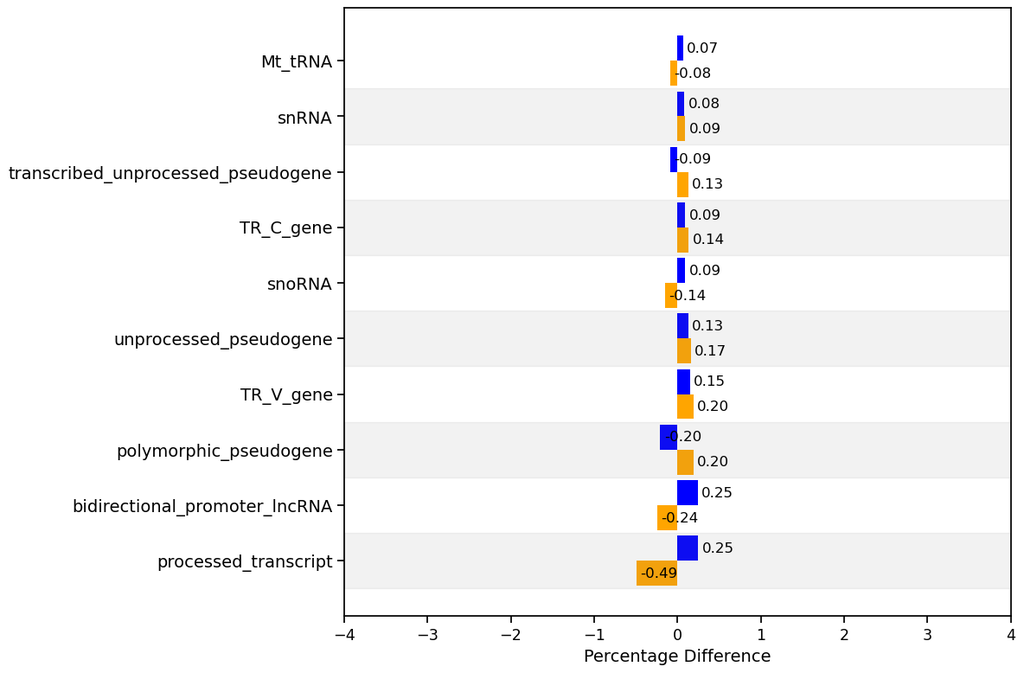

```python
# Use Seaborn to set context for better font readability
sns.set_context("notebook", font_scale=1.15)

# Extracting gene types and their corresponding diffs for the top contributors
gene_types = [x[0] for x in other_contributors_up[:top_contributors_count]]
diffs_up_short = [x[1] for x in other_contributors_up[:top_contributors_count]]
diffs_down_short = [x[1] for x in other_contributors_down[:top_contributors_count]]

# Determine the positions of the bars
ind = np.arange(len(gene_types))  # y locations for the gene types
width = 0.45  # width of the bars

# Create the figure and axis
fig, ax = plt.subplots(figsize=(12, 8))  # Increase figure size to use more white space

# Plot 'upregulated' bars
rects_up = ax.barh(ind - width/2, diffs_up_short, width, label='Upregulated vs Unregulated', color='orange')

# Plot 'downregulated' bars
rects_down = ax.barh(ind + width/2, diffs_down_short, width, label='Downregulated vs Unregulated', color='blue')

# Attach annotations to both sets of bars for clarity
def attach_annotations(rects):
    for rect in rects:
        width = rect.get_width()
        ax.annotate(f'{width:.2f}',
                    xy=(width, rect.get_y() + rect.get_height() / 2),
                    xytext=(3, 0),  # 3 points horizontal offset
                    textcoords="offset points",
                    ha='left', va='center',
                    fontsize=12)  # Increase font size for annotations

attach_annotations(rects_up)
attach_annotations(rects_down)

# Add shading to each category
for i in range(len(gene_types)):
    if i % 2 == 0:
        ax.axhspan(i - 0.5, i + 0.5, color='gray', alpha=0.1)

# Labels, title, and custom y-axis tick labels
ax.set_xlabel('Percentage Difference', fontsize=14)  # Increase font size for better readability
# ax.set_title('Contributions to "Other" Category for Upregulated and Downregulated Gene Types', fontsize=16)
ax.set_yticks(ind)
ax.set_yticklabels(gene_types, rotation=0, fontsize=14)  # Increase font size and ensure proper rotation
# ax.legend(fontsize=12)

# Adjust layout for better visibility
plt.tight_layout()
plt.xlim(-4, 4)

# Save the plot to a file
biotype_plot_path = os.path.join(output_dir, "Biotype_differences_plot_contributer_others.svg")
plt.savefig(biotype_plot_path, format="svg", bbox_inches='tight')
plt.show()
```

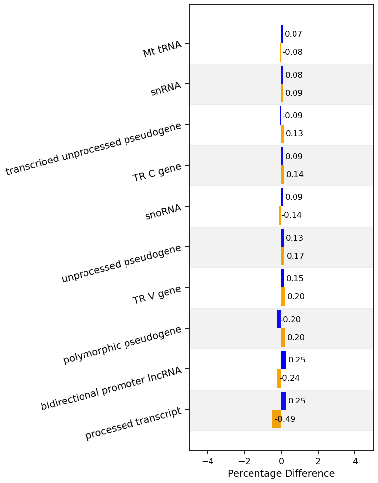

```python
# Use Seaborn to set context for better font readability
sns.set_context("notebook", font_scale=1.15)

# Extracting gene types and their corresponding diffs for the top contributors
gene_types = [x[0] for x in other_contributors_up[:top_contributors_count]]
diffs_up_short = [x[1] for x in other_contributors_up[:top_contributors_count]]
diffs_down_short = [x[1] for x in other_contributors_down[:top_contributors_count]]

# Determine the positions of the bars
ind = np.arange(len(gene_types))  # y locations for the gene types
width = 0.45  # width of the bars

# Create the figure and axis
fig, ax = plt.subplots(figsize=(8, 10))  # Increase figure size to use more white space

# Plot 'upregulated' bars
rects_up = ax.barh(ind - width/2, diffs_up_short, width, label='Upregulated vs Unregulated', color='orange')

# Plot 'downregulated' bars
rects_down = ax.barh(ind + width/2, diffs_down_short, width, label='Downregulated vs Unregulated', color='blue')

# Attach annotations to both sets of bars for clarity
def attach_annotations(rects):
    for rect in rects:
        width = rect.get_width()
        ax.annotate(f'{width:.2f}',
                    xy=(width, rect.get_y() + rect.get_height() / 2),
                    xytext=(3, 0),  # 3 points horizontal offset
                    textcoords="offset points",
                    ha='left', va='center',
                    fontsize=12)  # Increase font size for annotations

attach_annotations(rects_up)
attach_annotations(rects_down)

# Add shading to each category
for i in range(len(gene_types)):
    if i % 2 == 0:
        ax.axhspan(i - 0.5, i + 0.5, color='gray', alpha=0.1)

# Labels, title, and custom y-axis tick labels
ax.set_xlabel('Percentage Difference', fontsize=14)  # Increase font size for better readability
# ax.set_title('Contributions to "Other" Category for Upregulated and Downregulated Gene Types', fontsize=16)
ax.set_yticks(ind)
ax.set_yticklabels([gt.replace('_', ' ') for gt in gene_types], rotation=15, fontsize=14)  # Increase font size and replace underscores

# Adjust layout for better visibility
plt.tight_layout()
plt.xlim(-5, 5)

# Save the plot to a file
biotype_plot_path = os.path.join(output_dir, "Biotype_differences_plot_contributer_others_final.svg")
plt.savefig(biotype_plot_path, format="svg", bbox_inches='tight')
plt.show()
```

Below is a code block that can help visualize the composition of the 'other' category. The commented out qualifiers can be reincluded to illustrate all contributions but some are less than <0.01%> and make the plot cluttered, so I opted to remove a few of these for better plot scaling and readability.

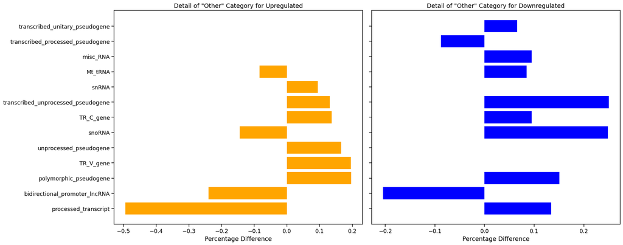

```python
# Extract biotypes contributing to "Other" category with their differences
other_contributors_up = []
other_contributors_down = []

for g_type in all_gene_types:
    up_diff = calc_diff('upregulated', g_type)
    down_diff = calc_diff('downregulated', g_type)
    if abs(up_diff) <= DIFFERENCE_CUTOFF and abs(down_diff) <= DIFFERENCE_CUTOFF:
        # This gene type contributes to the "Other" category
        other_contributors_up.append((g_type, up_diff))
        other_contributors_down.append((g_type, down_diff))

# Sort contributors by the difference magnitude for upregulated and downregulated
other_contributors_up.sort(key=lambda x: abs(x[1]), reverse=True)
other_contributors_down.sort(key=lambda x: abs(x[1]), reverse=True)

# Extract gene types and difference values (for nicer plotting, take just a few top contributors)
top_contributors_count = 10  # or adjust based on how many you wish to display
gene_types_up, diffs_up = zip(*other_contributors_up[:top_contributors_count])
gene_types_down, diffs_down = zip(*other_contributors_down[:top_contributors_count])

# Plotting
fig, axs = plt.subplots(1, 2, figsize=(20, 8), sharey=True)

# 'Upregulated Other' segmentation
axs[0].barh(gene_types_up, diffs_up, color='orange')
axs[0].set_title('Detail of "Other" Category for Upregulated')
axs[0].set_xlabel('Percentage Difference')

# 'Downregulated Other' segmentation
axs[1].barh(gene_types_down, diffs_down, color='blue')
axs[1].set_title('Detail of "Other" Category for Downregulated')
axs[1].set_xlabel('Percentage Difference')

plt.tight_layout()
plt.show()
```

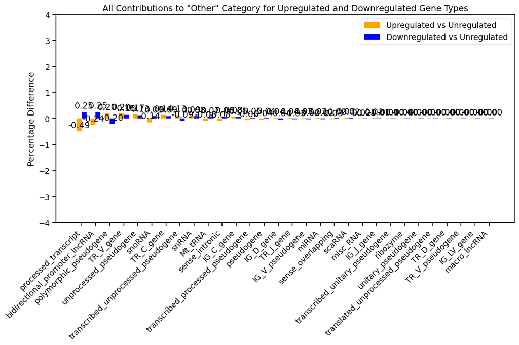

```python
# Continues from the calculation of 'other_contributors_up' and 'other_contributors_down'

# # This block is for a visualization that only includes singnifigantly contributing other gene biotypes
# # Extracting gene types and their corresponding diffs for the top contributors
# gene_types = [x[0] for x in other_contributors_up[:top_contributors_count]]
# diffs_up_short = [x[1] for x in other_contributors_up[:top_contributors_count]]
# diffs_down_short = [x[1] for x in other_contributors_down[:top_contributors_count]]  # Use positive values for simplicity in visualization

# Extracting gene types and their corresponding diffs for the top contributors
gene_types = [x[0] for x in other_contributors_up]
diffs_up_short = [x[1] for x in other_contributors_up]
diffs_down_short = [x[1] for x in other_contributors_down]  # Use positive values for simplicity in visualization

# Determine the positions of the bars
ind = np.arange(len(gene_types))  # the x locations for the gene types
width = 0.35  # the width of the bars

fig, ax = plt.subplots(figsize=(12, 8))

# Plot 'upregulated' bars
rects_up = ax.bar(ind - width/2, diffs_up_short, width, label='Upregulated vs Unregulated', color='orange')

# Plot 'downregulated' bars
rects_down = ax.bar(ind + width/2, diffs_down_short, width, label='Downregulated vs Unregulated', color='blue')

def attach_annotations(rects):
    """Attach a text label above each bar in *rects*, displaying its height."""
    for rect in rects:
        height = rect.get_height()
        ax.annotate(f'{height:.2f}',
                    xy=(rect.get_x() + rect.get_width() / 2, height),
                    xytext=(0, 3),  # 3 points vertical offset
                    textcoords="offset points",
                    ha='center', va='bottom')

# Adding annotations to both sets of bars for clarity
attach_annotations(rects_up)
attach_annotations(rects_down)

# Labels, title and custom x-axis tick labels
ax.set_ylabel('Percentage Difference')
ax.set_title('All Contributions to "Other" Category for Upregulated and Downregulated Gene Types')
ax.set_xticks(ind)
ax.set_xticklabels(gene_types, rotation=45, ha="right")
ax.legend()

# Adjust layout for better visibility
plt.tight_layout()
plt.ylim(-4,4)
biotype_plot_path = os.path.join(output_dir, "Biotype_differences_plot_all_other.svg")
plt.savefig(biotype_plot_path, format="svg", bbox_inches='tight')
plt.show()
```

```python
!ls output/all_output
```

```
Biotype_differences_plot_all_other.svg
Biotype_differences_plot_all_tissues.svg
Biotype_differences_plot_contributer_others_final.svg
Biotype_differences_plot_contributer_others_FINAL.svg
Biotype_differences_plot_contributer_others.svg
Biotype_differences_plot_contributer_other.svg
Biotype_differences_plot_with_cutoff_all_tissues_final.svg
Biotype_differences_plot_with_cutoff_all_tissues_FINAL.svg
Biotype_differences_plot_with_cutoff_all_tissues.svg
other_down_composition_abs.svg
other_up_composition_abs.svg
pie_charts
volcano_plot_all_tissues.svg
volcano_plots
```

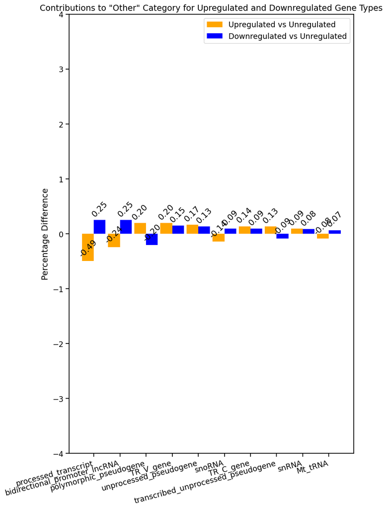

```python
# Setup Seaborn context for better font readability
sns.set_context("notebook", font_scale=1.15)
# Continues from the calculation of 'other_contributors_up' and 'other_contributors_down'

# This block is for a visualization that only includes singnifigantly contributing other gene biotypes
# Extracting gene types and their corresponding diffs for the top contributors
gene_types = [x[0] for x in other_contributors_up[:top_contributors_count]]
diffs_up_short = [x[1] for x in other_contributors_up[:top_contributors_count]]
diffs_down_short = [x[1] for x in other_contributors_down[:top_contributors_count]]  # Use positive values for simplicity in visualization

# # Extracting gene types and their corresponding diffs for the top contributors
# gene_types = [x[0] for x in other_contributors_up]
# diffs_up_short = [x[1] for x in other_contributors_up]
# diffs_down_short = [x[1] for x in other_contributors_down]  # Use positive values for simplicity in visualization

# Determine the positions of the bars
ind = np.arange(len(gene_types))  # the x locations for the gene types
width = 0.45  # the width of the bars

fig, ax = plt.subplots(figsize=(8.5, 12))

# Plot 'upregulated' bars
rects_up = ax.bar(ind - width/2, diffs_up_short, width, label='Upregulated vs Unregulated', color='orange')

# Plot 'downregulated' bars
rects_down = ax.bar(ind + width/2, diffs_down_short, width, label='Downregulated vs Unregulated', color='blue')

def attach_annotations(rects):
    """Attach a text label above each bar in *rects*, displaying its height."""
    for rect in rects:
        height = rect.get_height()
        ax.annotate(f'{height:.2f}',
                    xy=(rect.get_x() + rect.get_width() / 2, height),
                    xytext=(0, 3),  # 3 points vertical offset
                    textcoords="offset points",
                    ha='center', va='bottom',
                    rotation=45)  # Rotate text annotations by 45 degrees


# Adding annotations to both sets of bars for clarity
attach_annotations(rects_up)
attach_annotations(rects_down)

# Labels, title and custom x-axis tick labels
ax.set_ylabel('Percentage Difference')
ax.set_title('Contributions to "Other" Category for Upregulated and Downregulated Gene Types')
ax.set_xticks(ind)
ax.set_xticklabels(gene_types, rotation=15, ha="right")
ax.legend()

# Adjust layout for better visibility
plt.tight_layout()
plt.ylim(-4,4)
biotype_plot_path = os.path.join(output_dir, "Biotype_differences_plot_contributer_other.svg")
plt.savefig(biotype_plot_path, format="svg", bbox_inches='tight')
plt.show()
```

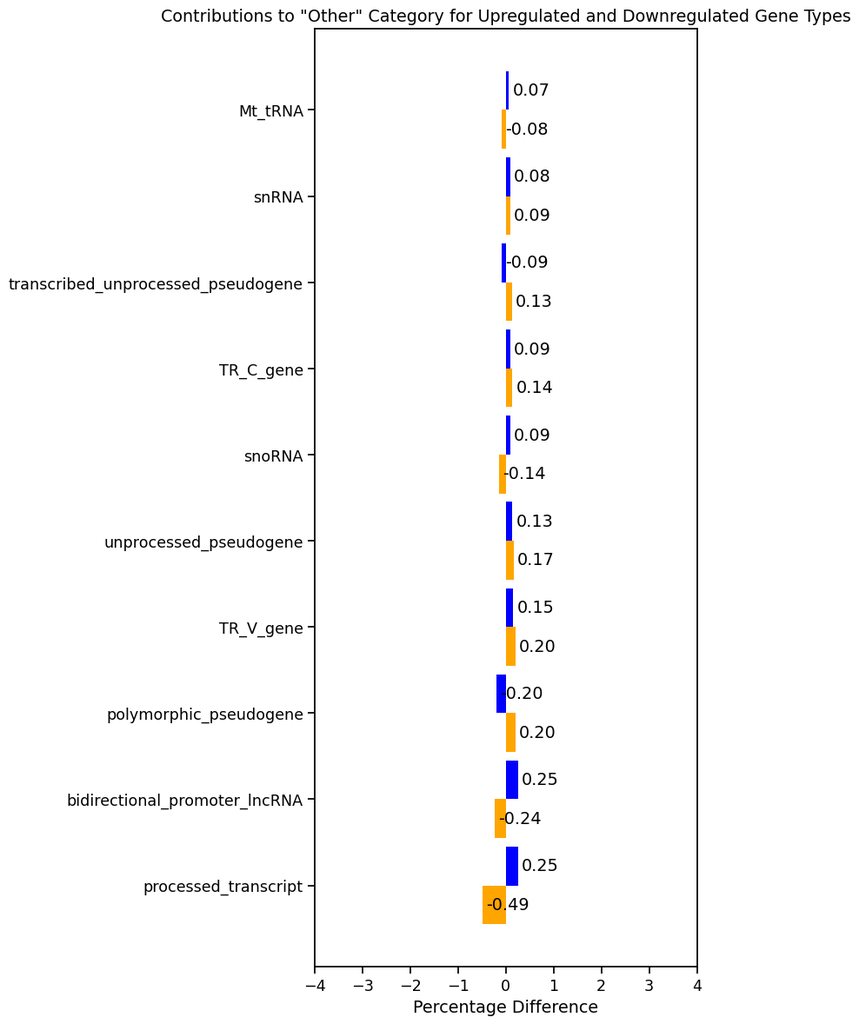

```python
# Setup Seaborn context for better font readability
sns.set_context("notebook", font_scale=1.15)

# Continues from the calculation of 'other_contributors_up' and 'other_contributors_down'
# This block is for a visualization that only includes significantly contributing other gene biotypes
# Extracting gene types and their corresponding diffs for the top contributors
gene_types = [x[0] for x in other_contributors_up[:top_contributors_count]]
diffs_up_short = [x[1] for x in other_contributors_up[:top_contributors_count]]
diffs_down_short = [x[1] for x in other_contributors_down[:top_contributors_count]] # Use positive values for simplicity in visualization

# Determine the positions of the bars
ind = np.arange(len(gene_types)) # the y locations for the gene types
width = 0.45 # the width of the bars

fig, ax = plt.subplots(figsize=(8.5, 12))

# Plot 'upregulated' bars
rects_up = ax.barh(ind - width/2, diffs_up_short, width, label='Upregulated vs Unregulated', color='orange')

# Plot 'downregulated' bars
rects_down = ax.barh(ind + width/2, diffs_down_short, width, label='Downregulated vs Unregulated', color='blue')

def attach_annotations(rects):
    """Attach a text label next to each bar in *rects*, displaying its width."""
    for rect in rects:
        width = rect.get_width()
        ax.annotate(f'{width:.2f}',
                    xy=(width, rect.get_y() + rect.get_height() / 2),
                    xytext=(3, 0), # 3 points horizontal offset
                    textcoords="offset points",
                    ha='left', va='center',
                    rotation=0) # Keep text annotations horizontal

# Adding annotations to both sets of bars for clarity
attach_annotations(rects_up)
attach_annotations(rects_down)

# Labels, title and custom y-axis tick labels
ax.set_xlabel('Percentage Difference')
ax.set_title('Contributions to "Other" Category for Upregulated and Downregulated Gene Types')
ax.set_yticks(ind)
ax.set_yticklabels(gene_types, rotation=0)
# ax.legend()

# Adjust layout for better visibility
plt.tight_layout()
plt.xlim(-4, 4)

biotype_plot_path = os.path.join(output_dir, "Biotype_differences_plot_contributer_others.svg")
plt.savefig(biotype_plot_path, format="svg", bbox_inches='tight')
plt.show()
```

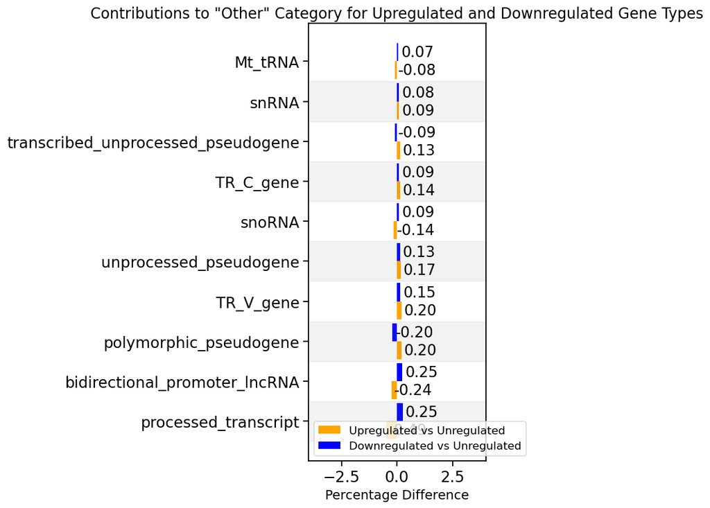

```python
import matplotlib.pyplot as plt
import seaborn as sns
import numpy as np

# Example data from prior calculation
# other_contributors_up and other_contributors_down should be defined based on prior scripts
gene_types = [x[0] for x in other_contributors_up]
diffs_up_short = [x[1] for x in other_contributors_up]
diffs_down_short = [x[1] for x in other_contributors_down]
top_contributors_count = 10  # Adjust as needed

# Use Seaborn to set context for better font readability
sns.set_context("notebook", font_scale=1.5)

# Extracting gene types and their corresponding diffs for the top contributors
gene_types = [x[0] for x in other_contributors_up[:top_contributors_count]]
diffs_up_short = [x[1] for x in other_contributors_up[:top_contributors_count]]
diffs_down_short = [x[1] for x in other_contributors_down[:top_contributors_count]]

# Determine the positions of the bars
ind = np.arange(len(gene_types))  # y locations for the gene types
width = 0.45  # width of the bars

# Create the figure and axis
fig, ax = plt.subplots(figsize=(8, 8))  # Increase figure size to use more white space

# Plot 'upregulated' bars
rects_up = ax.barh(ind - width/2, diffs_up_short, width, label='Upregulated vs Unregulated', color='orange')

# Plot 'downregulated' bars
rects_down = ax.barh(ind + width/2, diffs_down_short, width, label='Downregulated vs Unregulated', color='blue')

# Attach annotations to both sets of bars for clarity
def attach_annotations(rects):
    for rect in rects:
        width = rect.get_width()
        ax.annotate(f'{width:.2f}',
                    xy=(width, rect.get_y() + rect.get_height() / 2),
                    xytext=(3, 0),  # 3 points horizontal offset
                    textcoords="offset points",
                    ha='left', va='center',
                    fontsize=16)  # Increase font size for annotations

attach_annotations(rects_up)
attach_annotations(rects_down)

# Add shading to each category
for i in range(len(gene_types)):
    if i % 2 == 0:
        ax.axhspan(i - 0.5, i + 0.5, color='gray', alpha=0.1)

# Labels, title, and custom y-axis tick labels
ax.set_xlabel('Percentage Difference', fontsize=14)  # Increase font size for better readability
ax.set_title('Contributions to "Other" Category for Upregulated and Downregulated Gene Types', fontsize=16)
ax.set_yticks(ind)
ax.set_yticklabels(gene_types, rotation=0)  # Increase font size and ensure proper rotation
ax.legend(fontsize=12)

# Adjust layout for better visibility
plt.tight_layout()
plt.xlim(-4, 4)

# Save the plot to a file
biotype_plot_path = os.path.join(output_dir, "Biotype_differences_plot_contributer_others_final.svg")
plt.savefig(biotype_plot_path, format="svg", bbox_inches='tight')
plt.show()
```

Below is an ugly pie chart of all contributions to the other category

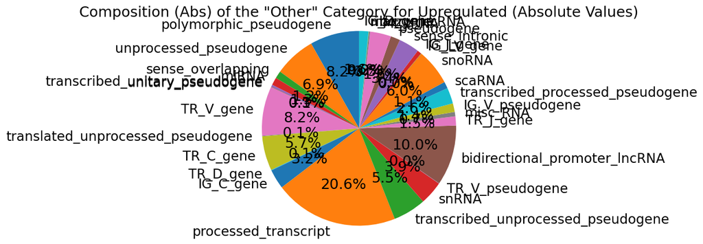

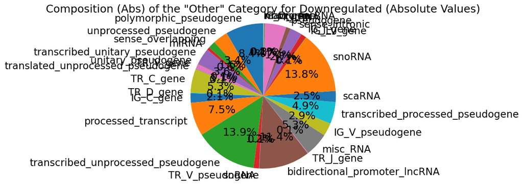

```python
import pandas as pd
import numpy as np
import matplotlib.pyplot as plt
import os
import glob

# Defined cutoff for differences
DIFFERENCE_CUTOFF = 0.5

base_path = '/mnt/work_1/gsgeorge/mus_musculus/figure2/output'
regulation_types = ['upregulated', 'downregulated', 'unregulated']
output_dir = '/mnt/work_1/gsgeorge/mus_musculus/figure2/output/all_output'

if not os.path.exists(output_dir):
    os.makedirs(output_dir)

dfs = {reg_type: pd.DataFrame() for reg_type in regulation_types}

for tissue in os.listdir(base_path):
    tissue_dir = os.path.join(base_path, tissue)
    if os.path.isdir(tissue_dir):
        for reg_type in regulation_types:
            for file in glob.glob(f'{tissue_dir}/{tissue}_{reg_type}_annotated.csv'):
                temp_df = pd.read_csv(file)
                dfs[reg_type] = pd.concat([dfs[reg_type], temp_df])

gene_biotype_percentages = {reg_type: {} for reg_type in regulation_types}

for reg_type in regulation_types:
    data = dfs[reg_type]
    total = len(data)
    counts = data['gene_biotype'].value_counts()
    percentages = (counts / total) * 100
    gene_biotype_percentages[reg_type] = percentages.to_dict()

all_gene_types = set()
for reg_type in gene_biotype_percentages.keys():
    all_gene_types.update(gene_biotype_percentages[reg_type].keys())

def calc_diff(up_or_down_type, g_type):
    unregulated = gene_biotype_percentages['unregulated'].get(g_type, 0)
    regulated = gene_biotype_percentages[up_or_down_type].get(g_type, 0)
    return regulated - unregulated

other_up = {}
other_down = {}

for g_type in all_gene_types:
    up_diff = calc_diff('upregulated', g_type)
    down_diff = calc_diff('downregulated', g_type)
    if abs(up_diff) <= DIFFERENCE_CUTOFF and abs(down_diff) <= DIFFERENCE_CUTOFF:
        if up_diff != 0:
            other_up[g_type] = up_diff
        if down_diff != 0:
            other_down[g_type] = down_diff
    else:
        # For significant differences, we'll still keep the calculation simple, ignoring them for pie charts
        pass

def plot_pie_chart(data, title, file_name):
    labels = list(data.keys())
    sizes = [abs(value) for value in data.values()]  # Use absolute values for sizes

    fig1, ax1 = plt.subplots()
    ax1.pie(sizes, labels=labels, autopct='%.1f%%', startangle=90)
    ax1.axis('equal')  # Equal aspect ratio ensures the pie chart is circular.
    new_title = title + " (Absolute Values)"
    plt.title(new_title)
    plt.savefig(os.path.join(output_dir, file_name), format="svg", bbox_inches='tight')
    plt.show()  # Close the figure after saving to avoid displaying it in non-interactive environments

# Adjust the titles if preferred, to reflect this change when calling the function
plot_pie_chart(other_up, 'Composition (Abs) of the "Other" Category for Upregulated', 'other_up_composition_abs.svg')
plot_pie_chart(other_down, 'Composition (Abs) of the "Other" Category for Downregulated', 'other_down_composition_abs.svg')
```

```python
import pandas as pd
import os

# Define the directory containing your updated CSV files
csv_directory="/mnt/work_1/gsgeorge/mus_musculus/figure2/output/BM"

# Initialize an empty set to store unique gene_biotype values
unique_biotypes = set()

# Loop through each file in the directory
for filename in os.listdir(csv_directory):
    if filename.endswith("_annotated.csv"):  # Check if the file is an updated CSV file
        file_path = os.path.join(csv_directory, filename)

        # Read the CSV file
        df = pd.read_csv(file_path)

        # Check if 'gene_biotype' column exists
        if 'gene_biotype' in df.columns:
            # Add unique values from the 'gene_biotype' column to the set
            unique_biotypes.update(df['gene_biotype'].dropna().unique())
        else:
            print(f"'gene_biotype' column not found in {filename}")

# Convert the set to a sorted list
biotypes_list = sorted(list(unique_biotypes))

# Display the unique gene biotypes
print("Unique Gene Biotypes Across All Files:")
for biotype in biotypes_list:
    print(biotype)
```

```
Unique Gene Biotypes Across All Files:
IG_C_gene
IG_D_gene
IG_J_gene
IG_V_gene
IG_V_pseudogene
Mt_tRNA
TEC
TR_C_gene
TR_V_gene
antisense
bidirectional_promoter_lncRNA
lincRNA
miRNA
misc_RNA
polymorphic_pseudogene
processed_pseudogene
processed_transcript
protein_coding
pseudogene
ribozyme
scaRNA
sense_intronic
sense_overlapping
snRNA
snoRNA
transcribed_processed_pseudogene
transcribed_unitary_pseudogene
transcribed_unprocessed_pseudogene
unprocessed_pseudogene
```

Now here I am going to conduct this bar plotting but this time never double counting any genes:

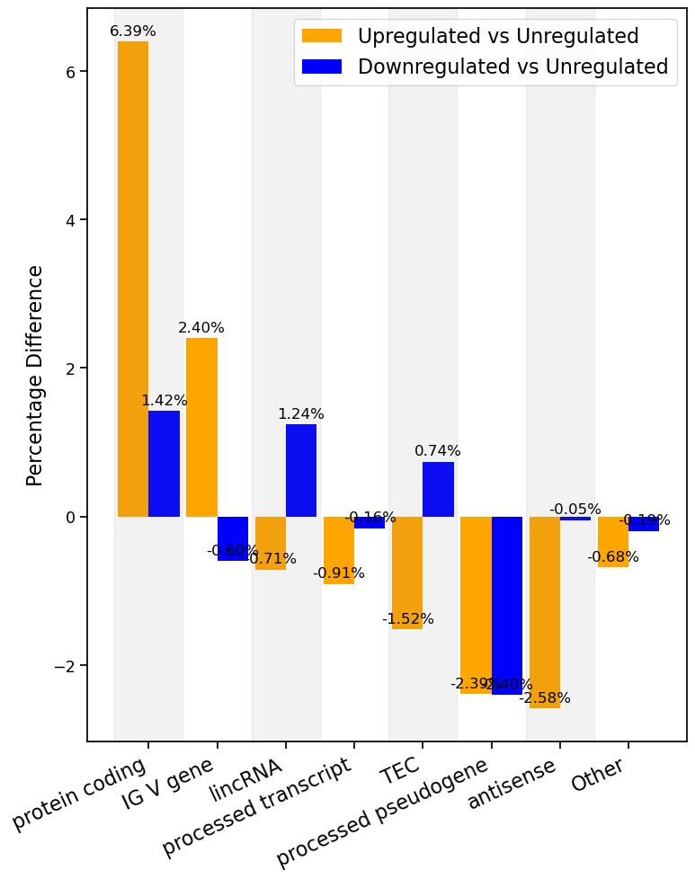

```python
import pandas as pd
import numpy as np
import matplotlib.pyplot as plt
import seaborn as sns
import os
import glob

# Set context for seaborn styling
sns.set_context("notebook", font_scale=1.15)

# Defined cutoff for differences
DIFFERENCE_CUTOFF = 0.5
base_path = '/mnt/work_1/gsgeorge/mus_musculus/figure2/output'
regulation_types = ['upregulated', 'downregulated', 'unregulated']
output_dir = '/mnt/work_1/gsgeorge/mus_musculus/figure2/output/all_output'
if not os.path.exists(output_dir):
    os.makedirs(output_dir)

dfs = {reg_type: pd.DataFrame() for reg_type in regulation_types}
for tissue in os.listdir(base_path):
    tissue_dir = os.path.join(base_path, tissue)
    if os.path.isdir(tissue_dir):
        for reg_type in regulation_types:
            for file in glob.glob(f'{tissue_dir}/{tissue}_{reg_type}_annotated.csv'):
                temp_df = pd.read_csv(file)
                dfs[reg_type] = pd.concat([dfs[reg_type], temp_df])

# Remove duplicates by keeping the iteration with the most significant |log2FoldChange|
for reg_type in dfs:
    dfs[reg_type]['abs_log2FoldChange'] = dfs[reg_type]['log2FoldChange'].abs()
    dfs[reg_type] = dfs[reg_type].sort_values('abs_log2FoldChange', ascending=False).drop_duplicates(subset='ID')

gene_biotype_percentages = {reg_type: {} for reg_type in regulation_types}
for reg_type in regulation_types:
    data = dfs[reg_type]
    total = len(data)
    counts = data['gene_biotype'].value_counts()
    percentages = (counts / total) * 100
    gene_biotype_percentages[reg_type] = percentages.to_dict()

all_gene_types = set()
for reg_type in gene_biotype_percentages.keys():
    all_gene_types.update(gene_biotype_percentages[reg_type].keys())

def calc_diff(up_or_down_type, g_type):
    unregulated = gene_biotype_percentages['unregulated'].get(g_type, 0)
    regulated = gene_biotype_percentages[up_or_down_type].get(g_type, 0)
    return regulated - unregulated

gene_biotype_diffs = []
other_category = ['Other', 0, 0]
for g_type in all_gene_types:
    up_diff = calc_diff('upregulated', g_type)
    down_diff = calc_diff('downregulated', g_type)
    if abs(up_diff) <= DIFFERENCE_CUTOFF and abs(down_diff) <= DIFFERENCE_CUTOFF:
        other_category[1] += up_diff  # Adding to 'Other' category for upregulated
        other_category[2] += down_diff  # Adding to 'Other' category for downregulated
    else:
        gene_biotype_diffs.append((g_type, up_diff, down_diff))

gene_biotype_diffs.sort(key=lambda x: x[1], reverse=True)
gene_biotype_diffs.append(tuple(other_category))

gene_types_sorted, up_diffs, down_diffs = zip(*gene_biotype_diffs)
ind = np.arange(len(gene_types_sorted))

# Replace underscores with spaces in gene_types_sorted
gene_types_sorted = [gt.replace("_", " ") for gt in gene_types_sorted]

fig, ax = plt.subplots(figsize=(8, 10))  # Increase the figure size to use more white space
width = 0.45
rects1 = ax.bar(ind - width / 2, up_diffs, width, label='Upregulated vs Unregulated', color="orange")
rects2 = ax.bar(ind + width / 2, down_diffs, width, label='Downregulated vs Unregulated', color="blue")

ax.set_ylabel('Percentage Difference', fontsize=16)  # Increase font size for better readability
# ax.set_title('Difference between Regulated and Unregulated by Gene Biotype', fontsize=16)
ax.set_xticks(ind)
ax.set_xticklabels(gene_types_sorted, rotation=25, ha='right', fontsize=16)  # Increase font size and rotate labels
ax.legend(fontsize=16)

# Add delineators and background shading for each category
for i in range(len(gene_types_sorted)):
    if i % 2 == 0:
        ax.axvspan(i - 0.5, i + 0.5, color='gray', alpha=0.1)

# Attach annotations
def attach_annotations(rects):
    for rect in rects:
        height = rect.get_height()
        ax.annotate(f'{height:.2f}%',
                    xy=(rect.get_x() + rect.get_width() / 2, height),
                    xytext=(0, 3), textcoords="offset points",
                    ha='center', va='bottom', fontsize=12)  # Increase font size for annotations

attach_annotations(rects1)
attach_annotations(rects2)

plt.tight_layout()

# Save the plot
biotype_plot_path = os.path.join(output_dir, "Biotype_differences_plot_with_cutoff_all_tissues_FINAL.svg")
plt.savefig(biotype_plot_path, format="svg", bbox_inches='tight')
plt.show()
```

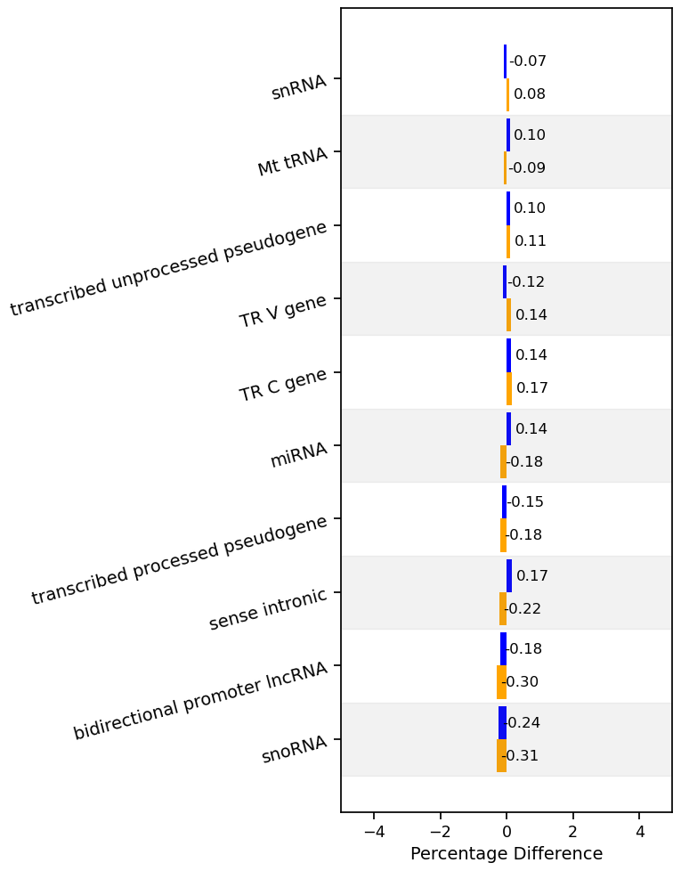

```python
import pandas as pd
import numpy as np
import matplotlib.pyplot as plt
import seaborn as sns
import os
import glob

# Function to read and concatenate CSV files, keeping only the iteration with the most significant |log2FoldChange|
def read_and_concatenate_most_significant_files(input_dir, regulation_types):
    all_genes = {reg_type: pd.DataFrame() for reg_type in regulation_types}
    for tissue in os.listdir(input_dir):
        tissue_dir = os.path.join(input_dir, tissue)
        if os.path.isdir(tissue_dir):
            for reg_type in regulation_types:
                for file in glob.glob(f'{tissue_dir}/{tissue}_{reg_type}_annotated.csv'):
                    temp_df = pd.read_csv(file)
                    all_genes[reg_type] = pd.concat([all_genes[reg_type], temp_df])

    for reg_type in all_genes:
        all_genes[reg_type]['abs_log2FoldChange'] = all_genes[reg_type]['log2FoldChange'].abs()
        all_genes[reg_type] = all_genes[reg_type].sort_values('abs_log2FoldChange', ascending=False).drop_duplicates(subset='ID')

    return all_genes

# Load data
base_path = '/mnt/work_1/gsgeorge/mus_musculus/figure2/output'
regulation_types = ['upregulated', 'downregulated', 'unregulated']
output_dir = '/mnt/work_1/gsgeorge/mus_musculus/figure2/output/all_output'
if not os.path.exists(output_dir):
    os.makedirs(output_dir)

dfs = read_and_concatenate_most_significant_files(base_path, regulation_types)

gene_biotype_percentages = {reg_type: {} for reg_type in regulation_types}
for reg_type in regulation_types:
    data = dfs[reg_type]
    total = len(data)
    counts = data['gene_biotype'].value_counts()
    percentages = (counts / total) * 100
    gene_biotype_percentages[reg_type] = percentages.to_dict()

all_gene_types = set()
for reg_type in gene_biotype_percentages.keys():
    all_gene_types.update(gene_biotype_percentages[reg_type].keys())

def calc_diff(up_or_down_type, g_type):
    unregulated = gene_biotype_percentages['unregulated'].get(g_type, 0)
    regulated = gene_biotype_percentages[up_or_down_type].get(g_type, 0)
    return regulated - unregulated

# Extract biotypes contributing to "Other" category with their differences
other_contributors_up = []
other_contributors_down = []

for g_type in all_gene_types:
    up_diff = calc_diff('upregulated', g_type)
    down_diff = calc_diff('downregulated', g_type)
    if abs(up_diff) <= DIFFERENCE_CUTOFF and abs(down_diff) <= DIFFERENCE_CUTOFF:
        # This gene type contributes to the "Other" category
        other_contributors_up.append((g_type, up_diff))
        other_contributors_down.append((g_type, down_diff))

# Sort contributors by the difference magnitude for upregulated and downregulated
other_contributors_up.sort(key=lambda x: abs(x[1]), reverse=True)
other_contributors_down.sort(key=lambda x: abs(x[1]), reverse=True)

# Extract gene types and difference values (for nicer plotting, take just a few top contributors)
top_contributors_count = 10  # or adjust based on how many you wish to display
gene_types_up, diffs_up = zip(*other_contributors_up[:top_contributors_count])
gene_types_down, diffs_down = zip(*other_contributors_down[:top_contributors_count])

# Use Seaborn to set context for better font readability
sns.set_context("notebook", font_scale=1.15)

# Extracting gene types and their corresponding diffs for the top contributors
gene_types = [x[0] for x in other_contributors_up[:top_contributors_count]]
diffs_up_short = [x[1] for x in other_contributors_up[:top_contributors_count]]
diffs_down_short = [x[1] for x in other_contributors_down[:top_contributors_count]]

# Determine the positions of the bars
ind = np.arange(len(gene_types))  # y locations for the gene types
width = 0.45  # width of the bars

# Create the figure and axis
fig, ax = plt.subplots(figsize=(8, 10))  # Increase figure size to use more white space

# Plot 'upregulated' bars
rects_up = ax.barh(ind - width/2, diffs_up_short, width, label='Upregulated vs Unregulated', color='orange')

# Plot 'downregulated' bars
rects_down = ax.barh(ind + width/2, diffs_down_short, width, label='Downregulated vs Unregulated', color='blue')

# Attach annotations to both sets of bars for clarity
def attach_annotations(rects):
    for rect in rects:
        width = rect.get_width()
        ax.annotate(f'{width:.2f}',
                    xy=(width, rect.get_y() + rect.get_height() / 2),
                    xytext=(3, 0),  # 3 points horizontal offset
                    textcoords="offset points",
                    ha='left', va='center',
                    fontsize=12)  # Increase font size for annotations

attach_annotations(rects_up)
attach_annotations(rects_down)

# Add shading to each category
for i in range(len(gene_types)):
    if i % 2 == 0:
        ax.axhspan(i - 0.5, i + 0.5, color='gray', alpha=0.1)

# Labels, title, and custom y-axis tick labels
ax.set_xlabel('Percentage Difference', fontsize=14)  # Increase font size for better readability
# ax.set_title('Contributions to "Other" Category for Upregulated and Downregulated Gene Types', fontsize=16)
ax.set_yticks(ind)
ax.set_yticklabels([gt.replace('_', ' ') for gt in gene_types], rotation=15, fontsize=14)  # Increase font size and replace underscores

# Adjust layout for better visibility
plt.tight_layout()
plt.xlim(-5, 5)

# Save the plot to a file
biotype_plot_path = os.path.join(output_dir, "Biotype_differences_plot_contributer_others_FINAL.svg")
plt.savefig(biotype_plot_path, format="svg", bbox_inches='tight')
plt.show()
```